# figure3

In This notebook I will use the upsetplot python package to make upset plots for all regulation categories illustrating the shared contributions to each between all tissuess.

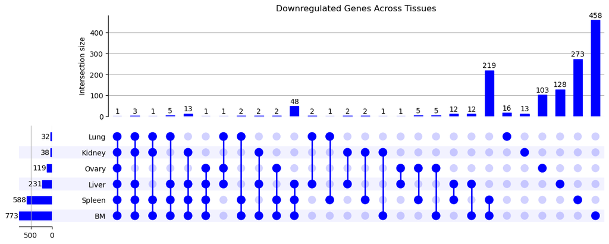

```
UpSet plot saved for downregulated genes at /mnt/work_1/gsgeorge/mus_musculus/figure3/output/all_output_upset_dir/downregulated_genes_across_tissues.svg
```

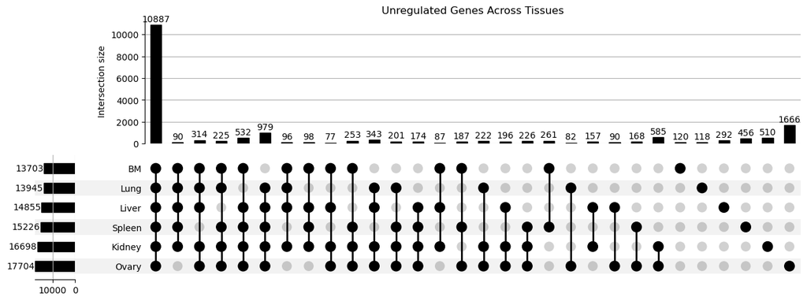

```
UpSet plot saved for unregulated genes at /mnt/work_1/gsgeorge/mus_musculus/figure3/output/all_output_upset_dir/unregulated_genes_across_tissues.svg
```

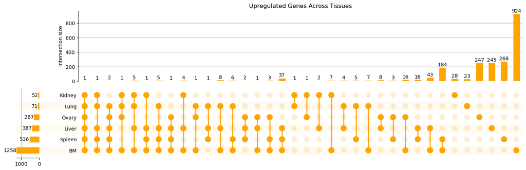

```
UpSet plot saved for upregulated genes at /mnt/work_1/gsgeorge/mus_musculus/figure3/output/all_output_upset_dir/upregulated_genes_across_tissues.svg
All plots generated successfully.
```

```python
import os
import pandas as pd
from upsetplot import from_contents, UpSet
import matplotlib.pyplot as plt

# Define the base working directory
work_dir = '/mnt/work_1/gsgeorge/mus_musculus/figure3'

# Output directory for saving plots
output_dir = os.path.join(work_dir, 'output', 'all_output_upset_dir')
if not os.path.exists(output_dir):
    os.makedirs(output_dir)

# Define the tissue samples and regulation types based on your structure
samples = ['BM', 'Kidney', 'Liver', 'Lung', 'Ovary', 'Spleen']
reg_types = ['downregulated', 'unregulated', 'upregulated']  # Lowercase to match file naming

# Assign colors for each regulation type
color_dict = {'upregulated': 'orange', 'downregulated': 'blue', 'unregulated': 'black'}

# Process each regulation type
for reg_type in reg_types:
    data_sets = {}

    # Gather gene IDs for each sample under the current regulation type
    for sample in samples:
        file_path = os.path.join(work_dir, 'output', sample, f"{sample}_{reg_type}_annotated.csv")

        if os.path.exists(file_path):
            data = pd.read_csv(file_path)
            # Assume the first column is 'ID'
            gene_ids = set(data.iloc[:, 0])
            data_sets[sample] = gene_ids
        else:
            print(f"File not found for {sample} in {reg_type} category.")

    # Prepare and display the UpSet plot if there are data_sets
    if data_sets:
        upset_data = from_contents(data_sets)
        plt.figure()
        upset = UpSet(upset_data, subset_size='count', sort_by="-degree", max_subset_rank=30,
                      facecolor=color_dict[reg_type], show_counts=True)
        upset.plot()
        plt.title(f"{reg_type.capitalize()} Genes Across Tissues")

        # Save the plot
        output_fig = os.path.join(output_dir, f"{reg_type}_genes_across_tissues.svg")
        plt.savefig(output_fig, format="svg")
        plt.show()
        print(f"UpSet plot saved for {reg_type} genes at {output_fig}")
    else:
        print(f"No data available for {reg_type} category.")

print("All plots generated successfully.")
```

Now, I am going to test to see if the origional file made by R includes all unique genes... as they should... and they do! this means my drop.na() worked during R biomart query and I can continue to research with confidence!

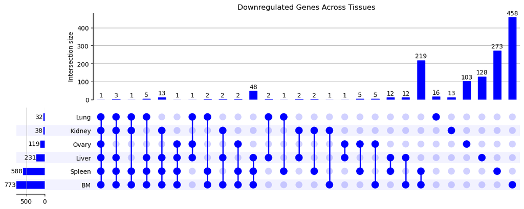

```
UpSet plot saved for downregulated genes at /mnt/work_1/gsgeorge/mus_musculus/figure3/output/all_output_upset_dir/downregulated_genes_across_tissues.svg
```

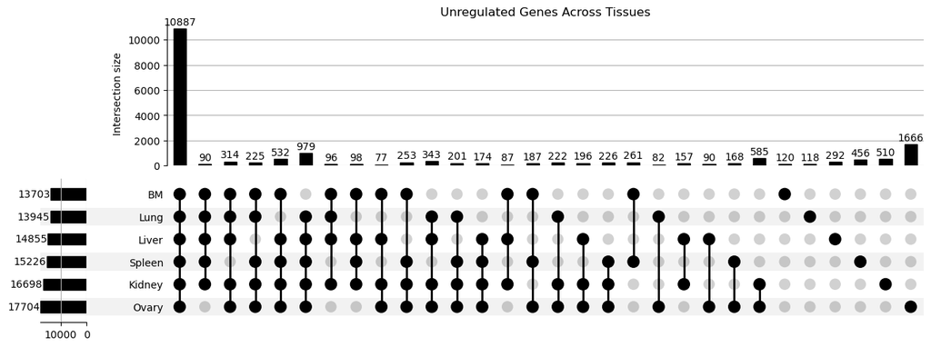

```
UpSet plot saved for unregulated genes at /mnt/work_1/gsgeorge/mus_musculus/figure3/output/all_output_upset_dir/unregulated_genes_across_tissues.svg
```

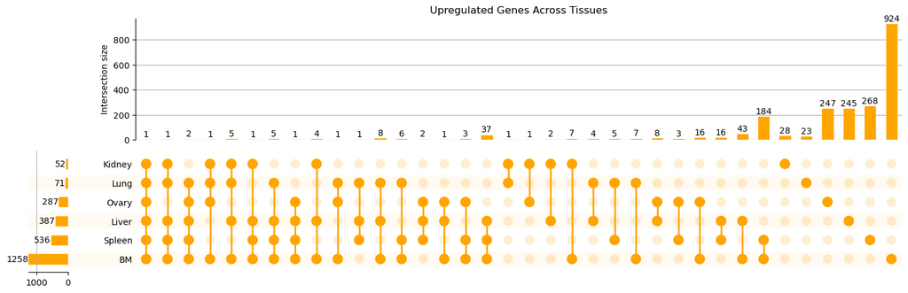

```
UpSet plot saved for upregulated genes at /mnt/work_1/gsgeorge/mus_musculus/figure3/output/all_output_upset_dir/upregulated_genes_across_tissues.svg
All plots generated successfully.
```

```python
# Process each regulation type
for reg_type in reg_types:
    data_sets = {}

    # Gather gene IDs for each sample under the current regulation type
    for sample in samples:
        file_path = os.path.join(work_dir, 'output', sample, f"{sample}_{reg_type}_annotated.csv")

        if os.path.exists(file_path):
            data = pd.read_csv(file_path)
            # Assume the first column is 'ID'
            gene_ids = set(data.iloc[:, 0])
            data_sets[sample] = gene_ids
        else:
            print(f"File not found for {sample} in {reg_type} category.")

    # Prepare and display the UpSet plot if there are data_sets
    if data_sets:
        upset_data = from_contents(data_sets)
        plt.figure(figsize=(12, 8))  # Specify figure size here
        upset = UpSet(upset_data, subset_size='count', sort_by="-degree", max_subset_rank=30,
                      facecolor=color_dict[reg_type], show_counts=True)
        upset.plot()
        plt.title(f"{reg_type.capitalize()} Genes Across Tissues")

        # Save the plot
        output_fig = os.path.join(output_dir, f"{reg_type}_genes_across_tissues.svg")
        plt.savefig(output_fig, format="svg")
        plt.show()
        print(f"UpSet plot saved for {reg_type} genes at {output_fig}")
    else:
        print(f"No data available for {reg_type} category.")

print("All plots generated successfully.")
```

```python
import pandas as pd
from itertools import combinations

# File paths and tissues specific.
files_to_analyze = {
    "BM": "output/BM/BM_upregulated_annotated.csv",
    "Kidney": "output/Kidney/Kidney_upregulated_annotated.csv",
    "Liver": "output/Liver/Liver_upregulated_annotated.csv",
    "Lung": "output/Lung/Lung_upregulated_annotated.csv",
    "Ovary": "output/Ovary/Ovary_upregulated_annotated.csv",
    "Spleen": "output/Spleen/Spleen_upregulated_annotated.csv"
}

# Create dictionaries to hold the gene sets for each file
tissue_genes = {t: set(pd.read_csv(f)['Gene.name']) for t, f in files_to_analyze.items()}

# Hold results of exclusive intersections
exclusively_upregulated = {}

# Get all possible combinations of tissue samples for proper intersections.
tissue_combinations = sum([list(combinations(tissue_genes.keys(), i)) for i in range(2, len(tissue_genes)+1)], [])

# Create Dictionary to store intersection results temporarily
all_combination_genes = {}

for combination in tissue_combinations:
    # Find intersected genes across the selected combination
    intersected_genes = set.intersection(*(tissue_genes[tissue] for tissue in combination))
    if intersected_genes:
        all_combination_genes[combination] = intersected_genes

# Populate exclusively upregulated
for base_comb in all_combination_genes:
    exclusive_genes = all_combination_genes[base_comb].copy()
    for other_comb in all_combination_genes:
        if set(base_comb) < set(other_comb):
            exclusive_genes -= all_combination_genes[other_comb]

    if exclusive_genes:
        exclusively_upregulated[base_comb] = exclusive_genes

# Display the final results that match the UpSet plot exclusive intersections
for comb, genes in exclusively_upregulated.items():
    print(f"Tissues: {' & '.join(comb)}")
    print("\n".join(genes))
    print("\n---\n")
```

```
Tissues: BM & Kidney
Ackr2
Wif1
Ccl8
Bcat1
Gbp6
H2-Aa
Aqp2

---

Tissues: BM & Liver
H2-T10
Adam23
3930402G23Rik
Ffar4
Grrp1
Ctla4
Gbp2b
Etnppl
Col12a1
Gprc5b
Ndufa4l2
Gm19585
Zbtb7c
Hmox1
H2-DMb1
Bmp3
Gm10451
Col5a3
Lama4
Vldlr
Gbp2
Slc1a3
Hapln1
Apol9b
Ramp3
Galnt15
Esm1
Ubd
```

[output cut: 442 more lines]

```
Tissues: BM & Kidney & Liver & Lung & Spleen
Gm32051

---

Tissues: BM & Liver & Lung & Ovary & Spleen
Serpina3g
Ccl12

---

Tissues: BM & Kidney & Liver & Lung & Ovary & Spleen
Apol11b

---
```

S1: Apol11b (MGI:3036248) S2: Gm32051 (MGI:5591210) NO RIBBON S3:Ccl12 (MGI:108224), Serpina3g (MGI:105046) S4: Ccl7 (MGI:99512) S5: Tgtp2 (MGI:3710083), H2-Q6 (MGI:95935), H2-Q7 (MGI:95936), Apoa4 (MGI:88051), H2-Q5 (MGI:95934) NO RIBBON S6: Rgs4 (MGI:108409) S7: Gvin1 (MGI:1921808), Serpina3f (MGI:2182838), Gdpd2 (MGI:1918834), Gzmb (MGI:109267), Gm4070 AKA Gvin2 (MGI:3782245) S8: Clec4n (MGI:1861231)

```python
import pandas as pd
from itertools import combinations

# File paths and corresponding tissue names for downregulated genes
files_to_analyze = {
    "BM": "output/BM/BM_downregulated_annotated.csv",
    "Kidney": "output/Kidney/Kidney_downregulated_annotated.csv",
    "Liver": "output/Liver/Liver_downregulated_annotated.csv",
    "Lung": "output/Lung/Lung_downregulated_annotated.csv",
    "Ovary": "output/Ovary/Ovary_downregulated_annotated.csv",
    "Spleen": "output/Spleen/Spleen_downregulated_annotated.csv"
}

# Load the data and create sets of genes for each tissue
tissue_genes = {tissue: set(pd.read_csv(filepath)['Gene.name']) for tissue, filepath in files_to_analyze.items()}

# Store the results of exclusive intersections
exclusively_downregulated = {}

# Generate all combinations of tissue sample sizes from 2 to the total number of tissues
tissue_combinations = sum([list(combinations(tissue_genes.keys(), i)) for i in range(2, len(tissue_genes)+1)], [])

# Store all intersections temporarily to correlate them later
all_combination_genes = {}
for combination in tissue_combinations:
    intersection_genes = set.intersection(*(tissue_genes[tissue] for tissue in combination))
    if intersection_genes:
        all_combination_genes[combination] = intersection_genes

# Determine exclusive genes for combinations by subtracting genes found in larger intersections
for base_comb in all_combination_genes:
    exclusive_genes = all_combination_genes[base_comb].copy()
    for other_comb in all_combination_genes:
        if set(base_comb) < set(other_comb):
            exclusive_genes -= all_combination_genes[other_comb]
    if exclusive_genes:
        exclusively_downregulated[base_comb] = exclusive_genes

# Output the results for each unique tissue combination
for comb, genes in exclusively_downregulated.items():
    print(f"Tissues: {' & '.join(comb)}")
    print("\n".join(genes))
    print("\n---\n")
```

```
Tissues: BM & Kidney
Akr1c6

---

Tissues: BM & Liver
Il1f9
Slc25a21
Ccr9
Hsd17b2
Mapt
Slc39a4
Tmem154
Nat8l
Osgin1
Aqp9
Paqr7
Il18rap

---

Tissues: BM & Ovary
Ppp1r3d
Prss34
Aatk
Ldhc
Arhgap9

---

Tissues: BM & Spleen
Thsd7b
Cass4
Alox12
Prss50
Rgs9bp
Slc38a9
Crtac1
Pln
Gm39321
```

[output cut: 373 more lines]

```
Ceacam10

---

Tissues: BM & Kidney & Liver & Lung & Spleen
Cxcr2
Stfa1
Stfa2l1

---

Tissues: BM & Kidney & Liver & Lung & Ovary & Spleen
Zfp36l2

---
```

S1: Zfp36l2 (MGI:107945) S2: Stfa1 (MGI:106198), Stfa2l1 (MGI:3524944), Cxcr2 (MGI:105303)

S3: F630028O10Rik AKA Mir223hg (MGI:3641813) (NORIBBON)

S4: Treml1 (MGI:1918576), Tubb1 (MGI:107814), Rgs18 (MGI:1927498), Nrgn (MGI:1927184), Gp9 (MGI:1860137) S5: Stfa3 (MGI:106196), Mpo (MGI:97137), Prg2 (MGI:103294), Stfa2 (MGI:106197), S100a8 (MGI:88244), S100a9 (MGI:1338947), Camp (MGI:108443), Chil3 (MGI:1330860), Ear1 (MGI:108021), Epx (MGI:107569), Mmp8 (MGI:1202395), Retnlg (MGI:2667763), Ear6 (MGI:1890463) S6: Ceacam10 (MGI:1347248)

```python
    import pandas as pd
    df = pd.read_csv('output/BM/BM_upregulated_annotated.csv')
    print(len(df))
```

```
1258
```

```python
    import pandas as pd
    df = pd.read_csv('output/BM/BM_upregulated_annotated.csv')
    unique_ids = df['ID'].nunique()  # Assuming 'ID' is the column name for gene IDs
    print(unique_ids)
```

```
1258
```

The below code block will output any douplicated ID in any of the files you want to test, in this case, we have none!

```python
import pandas as pd

# Load the CSV file
df = pd.read_csv('output/BM/BM_upregulated_annotated.csv')

# Find duplicated IDs
duplicated_ids = df[df.duplicated('ID', keep=False)]  # 'keep=False' will mark all duplicates as True

# Display the duplicated IDs
print(duplicated_ids)
```

```
Empty DataFrame
Columns: [ID, log2FoldChange, pvalue, padj, KO1.BMcells, KO2.BMcells, KO3.BMcells, KO4.BMcells, KO5.BMcells, WT1.BMcells, WT2.BMcells, WT3.BMcells, WT4.BMcells, WT5.BMcells, Gene.name, gene_biotype, Coding/Non-coding, Regulation]
Index: []
```

```python
# !head output/*/*.csv
!pwd
```

```
/mnt/work_1/gsgeorge/mus_musculus/figure3
```

```python
import pandas as pd
from collections import Counter

# Define the files to be analyzed
files_to_analyze = [
    "output/BM/BM_upregulated_annotated.csv",
    "output/Kidney/Kidney_upregulated_annotated.csv",
    "output/Liver/Liver_upregulated_annotated.csv",
    "output/Lung/Lung_upregulated_annotated.csv",
    "output/Ovary/Ovary_upregulated_annotated.csv",
    "output/Spleen/Spleen_upregulated_annotated.csv"
]

# Initialize a list to hold all upregulated genes from all files
all_upregulated_genes = []

for file in files_to_analyze:
    # Load the CSV file
    data = pd.read_csv(file)
    # Append the gene names of upregulated genes to the list
    all_upregulated_genes.extend(data['Gene.name'].tolist())

# Count the occurrences of each gene in the list
gene_counter = Counter(all_upregulated_genes)

# Genes upregulated
genes_upregulated = [gene for gene, count in gene_counter.items() if count >= 1]

# Genes upregulated in 1 tissue
genes_upregulated_in_1_tissue = [gene for gene, count in gene_counter.items() if count == 1]

# Genes upregulated in two tissues
genes_upregulated_in_2_tissues = [gene for gene, count in gene_counter.items() if count == 2]

# Genes upregulated in at least 3 different tissues
genes_upregulated_in_3_or_more_tissues = [gene for gene, count in gene_counter.items() if count == 3]

# Genes upregulated in at least 4 different tissues
genes_upregulated_in_4_or_more_tissues = [gene for gene, count in gene_counter.items() if count == 4]

# Genes upregulated in at least 5 different tissues
genes_upregulated_in_5_or_more_tissues = [gene for gene, count in gene_counter.items() if count == 5]

# Display the results
print("\nGenes upregulated")
for gene in genes_upregulated:
    print(gene)

print("\nGenes upregulated in 1 tissue:")
for gene in genes_upregulated_in_1_tissue:
    print(gene)


print("\nGenes upregulated in 2 tissues:")
for gene in genes_upregulated_in_2_tissues:
    print(gene)

print("\nGenes upregulated in 3 or more tissues:")
for gene in genes_upregulated_in_3_or_more_tissues:
    print(gene)


print("\nGenes upregulated in 4 or more tissues:")
for gene in genes_upregulated_in_4_or_more_tissues:
    print(gene)



print("\nGenes upregulated in 5 tissues:")
for gene in genes_upregulated_in_5_or_more_tissues:
    print(gene)
```

```
Genes upregulated
Tbx2
Fgf23
Gmpr
Mid2
Fap
Sox9
Loxl3
Serpinf1
Tcf7
Luzp1
Col6a1
Timp1
Ckb
Tbx21
Col1a1
Sgca
Dlx3
Tulp3
Fkbp10
Hoxc8
Hoxc6
Tat
Lrp3
Cd3g
Rab34
Ppm1j
Ppard
Angptl4
Scin
Ikzf4
Prkd1
Fkbp7
Grin2d
Plin4
Efna2
Cacnb3
Fkbp11
Fcgrt
Cp
```

[output cut: 4177 more lines]

```
Apoa4
Ccl7
Rgs4
Gvin1
H2-Q5
H2-Q7
Serpina3f
H2-Q6
Gm4070
Tgtp2

Genes upregulated in 5 tissues:
Ccl12
Serpina3g
Gm32051
```

```python
import pandas as pd

from collections import Counter



# Define the files to be analyzed

files_to_analyze = [

    "output/BM/BM_upregulated_annotated.csv",

    "output/Kidney/Kidney_upregulated_annotated.csv",

    "output/Liver/Liver_upregulated_annotated.csv",

    "output/Lung/Lung_upregulated_annotated.csv",

    "output/Ovary/Ovary_upregulated_annotated.csv",

    "output/Spleen/Spleen_upregulated_annotated.csv"

]



# Initialize a set to hold all unique upregulated protein-coding genes from all files

unique_protein_coding_genes = set()



for file in files_to_analyze:

    # Load the CSV file

    data = pd.read_csv(file)

    # Filter the DataFrame for protein-coding genes

    protein_coding_data = data[data['gene_biotype'] == 'protein_coding']

    # Update the set with the gene names of upregulated protein-coding genes

    unique_protein_coding_genes.update(protein_coding_data['ID'].tolist())



# Convert the set to a sorted list for easier viewing

unique_protein_coding_genes = sorted(list(unique_protein_coding_genes))



# Display the results

print("Unique Upregulated Protein-Coding Genes:")

for gene in unique_protein_coding_genes:

    print(gene)
```

```
Unique Upregulated Protein-Coding Genes:
ENSMUSG00000000093
ENSMUSG00000000120
ENSMUSG00000000157
ENSMUSG00000000182
ENSMUSG00000000253
ENSMUSG00000000266
ENSMUSG00000000392
ENSMUSG00000000567
ENSMUSG00000000693
ENSMUSG00000000730
ENSMUSG00000000753
ENSMUSG00000000782
ENSMUSG00000000982
ENSMUSG00000001089
ENSMUSG00000001119
ENSMUSG00000001131
ENSMUSG00000001227
ENSMUSG00000001270
ENSMUSG00000001435
ENSMUSG00000001444
ENSMUSG00000001467
ENSMUSG00000001494
ENSMUSG00000001506
ENSMUSG00000001508
ENSMUSG00000001510
ENSMUSG00000001521
ENSMUSG00000001555
ENSMUSG00000001657
ENSMUSG00000001661
ENSMUSG00000001670
ENSMUSG00000001802
ENSMUSG00000001827
ENSMUSG00000001865
ENSMUSG00000001930
ENSMUSG00000001988
ENSMUSG00000002033
ENSMUSG00000002059
ENSMUSG00000002228
ENSMUSG00000002250
```

[output cut: 1765 more lines]

```
ENSMUSG00000103332
ENSMUSG00000103472
ENSMUSG00000103567
ENSMUSG00000103585
ENSMUSG00000103677
ENSMUSG00000103749
ENSMUSG00000103793
ENSMUSG00000104063
ENSMUSG00000104346
ENSMUSG00000104713
ENSMUSG00000105504
ENSMUSG00000105734
ENSMUSG00000106379
ENSMUSG00000108841
ENSMUSG00000110195
```

4+ MGI:109267 MGI:1918834 MGI:1099443 MGI:1923324 MGI:108409 MGI:1921808 MGI:1891125 MGI:3584036 MGI:1340026 MGI:95934 (none) MGI:1315202 MGI:95936 MGI:2182838 MGI:3710083 MGI:2429943 MGI:5591210

```python
import pandas as pd
from collections import Counter

# Define the files to be analyzed, now focusing on downregulated genes
files_to_analyze = [
    "output/BM/BM_downregulated_annotated.csv",
    "output/Kidney/Kidney_downregulated_annotated.csv",
    "output/Liver/Liver_downregulated_annotated.csv",
    "output/Lung/Lung_downregulated_annotated.csv",
    "output/Ovary/Ovary_downregulated_annotated.csv",
    "output/Spleen/Spleen_downregulated_annotated.csv"
]

# Initialize a list to hold all downregulated genes from all files
all_downregulated_genes = []

for file in files_to_analyze:
    # Load the CSV file
    data = pd.read_csv(file)
    # Append the gene names of downregulated genes to the list
    all_downregulated_genes.extend(data['Gene.name'].tolist())

# Count the occurrences of each gene in the list
gene_counter = Counter(all_downregulated_genes)

# Genes downregulated
genes_downregulated = [gene for gene, count in gene_counter.items() if count >= 1]

# Genes downregulated in 1 tissue
genes_downregulated_in_1_tissue = [gene for gene, count in gene_counter.items() if count == 1]

# Genes downregulated in two tissues
genes_downregulated_in_2_tissues = [gene for gene, count in gene_counter.items() if count == 2]

# Genes downregulated in at least 3 different tissues
genes_downregulated_in_3_or_more_tissues = [gene for gene, count in gene_counter.items() if count == 3]

# Genes downregulated in at least 4 different tissues
genes_downregulated_in_4_or_more_tissues = [gene for gene, count in gene_counter.items() if count >= 4]

# Genes downregulated in at least 5 different tissues
genes_downregulated_in_5_or_more_tissues = [gene for gene, count in gene_counter.items() if count >= 6]

# Display the results
print("\nGenes downregulated")
for gene in genes_downregulated:
    print(gene)

print("\nGenes downregulated in 1 tissue:")
for gene in genes_downregulated_in_1_tissue:
    print(gene)

print("\nGenes downregulated in 2 tissues:")
for gene in genes_downregulated_in_2_tissues:
    print(gene)

print("\nGenes downregulated in 3 tissues:")
for gene in genes_downregulated_in_3_or_more_tissues:
    print(gene)

print("\nGenes downregulated in 4 or more tissues:")
for gene in genes_downregulated_in_4_or_more_tissues:
    print(gene)

print("\nGenes downregulated in 6 tissues:")
for gene in genes_downregulated_in_5_or_more_tissues:
    print(gene)
```

```
Genes downregulated
Scml2
Klf6
Itgb2l
Itgb2
Alox12
Adora3
Btn1a1
Il4
Ccl3
S100a6
Hpn
Gstt1
Cldn15
Gria3
Rapsn
Spi1
Slc25a42
Dennd1c
Pnkp
Klf4
Tbc1d8
Slc2a3
Ebi3
Cyp4f18
Prodh
Hlf
Ctse
Cd33
Aqp1
Abca13
Mapk13
Sh2b2
4930550C14Rik
Il5ra
Igf1r
Mrvi1
Kit
Mmp8
Sqor
```

[output cut: 2619 more lines]

```
Zfp36l2
Epx
Nrgn
Ceacam10
Stfa3
S100a8
S100a9
Stfa2l1
Ear6
Stfa1
Ear1
F630028O10Rik

Genes downregulated in 6 tissues:
Zfp36l2
```

```python
# Define the files for each tissue
tissues_files = {
    'Bone Marrow': "output/BM/BM_upregulated_annotated.csv",
    'Kidney': "output/Kidney/Kidney_upregulated_annotated.csv",
    'Liver': "output/Liver/Liver_upregulated_annotated.csv",
    'Lung': "output/Lung/Lung_upregulated_annotated.csv",
    'Ovary': "output/Ovary/Ovary_upregulated_annotated.csv",
    'Spleen': "output/Spleen/Spleen_upregulated_annotated.csv"
}

# Function to load genes from a file
def load_genes(file_path):
    data = pd.read_csv(file_path)
    return set(data['Gene.name'])

# Load genes for each tissue
tissues_genes = {tissue: load_genes(file) for tissue, file in tissues_files.items()}

# Find unique genes upregulated in each tissue
unique_genes_by_tissue = {}

for tissue, genes in tissues_genes.items():
    other_tissues_genes = set().union(*(genes_set for other_tissue, genes_set in tissues_genes.items() if other_tissue != tissue))
    unique_genes = genes.difference(other_tissues_genes)
    unique_genes_by_tissue[tissue] = unique_genes

# Output the unique genes for each tissue
for tissue, genes in unique_genes_by_tissue.items():
    print(f"Unique genes upregulated in {tissue}:")
    for gene in genes:
        print(gene)
    print("\n")
```

```
Unique genes upregulated in Bone Marrow:
Bcar1
Enpep
Trbv16
Csmd1
Pycr1
Dmpk
Trbv13-2
Fkbp9
Selenow
Kank2
Fhod3
Rhbdl3
Syndig1l
Gm20056
Serpinh1
Pcdhgb2
Ptges3l
Mlip
Klf15
Hoxd8
Arhgef19
Unc5c
Gm17767
Slc29a4
Nkd2
Camk4
Scimp
Lmo7
Mkx
Bicc1
Plekhh3
Plb1
B4galnt3
Pltp
Acan
Hfm1
Rhpn1
Ptk2
Cttnbp2nl
```

[output cut: 1694 more lines]

```
Hgf
Igkv4-68
Pgf
Scara5
Ror1
Atp12a
Ighv10-3
Cyp11a1
1700069B07Rik
Reep6
Ccdc87
Ctsf
Map6d1
Magee2
Adora1
```

```python
import pandas as pd

# Define the files to be analyzed, now focusing on downregulated genes
files_to_analyze = {
    "BM": "output/BM/BM_downregulated_annotated.csv",
    "Kidney": "output/Kidney/Kidney_downregulated_annotated.csv",
    "Liver": "output/Liver/Liver_downregulated_annotated.csv",
    "Lung": "output/Lung/Lung_downregulated_annotated.csv",
    "Ovary": "output/Ovary/Ovary_downregulated_annotated.csv",
    "Spleen": "output/Spleen/Spleen_downregulated_annotated.csv"
}

# Dictionary to store gene lists for each tissue
tissue_genes = {}

# Read in the data for each tissue
for tissue, file in files_to_analyze.items():
    data = pd.read_csv(file)
    tissue_genes[tissue] = set(data['Gene.name'].tolist())

# Determine unique genes for each tissue
unique_genes_by_tissue = {}
for tissue, genes in tissue_genes.items():
    other_genes = set()
    for other_tissue, other_gene_list in tissue_genes.items():
        if other_tissue != tissue:
            other_genes.update(other_gene_list)
    unique_genes_by_tissue[tissue] = genes.difference(other_genes)

# Print the unique genes in each tissue
for tissue, unique_genes in unique_genes_by_tissue.items():
    print(f"\nUnique genes downregulated in {tissue}:")
    for gene in unique_genes:
        print(gene)
```

```
Unique genes downregulated in BM:
Il1b
Gm37691
Cbln3
Tacstd2
Chil5
Tmigd3
Clec4a2
Gm16192
Rhou
Fpr1
Gm807
Slc7a11
5830432E09Rik
Sorl1
Cebpd
Gm7514
Cebpb
Csf3r
Stx3
Ptgs2os2
Ccdc180
Fcgr3
Gm15832
Ica1l
1700102P08Rik
Cxcl5
Ncf1
Dusp1
Gm16104
Mcmdc2
Tgm3
E230014E18Rik
Hnmt
Tob1
Pnpla7
Ankrd63
Gm44401
Adam8
Gm11772
```

[output cut: 946 more lines]

```
Barx1
Hoxa7
Lmntd2
Ctrb1
Gmfg
Zswim5
P4htm
Gm43864
Ripor3
Gm26813
Try10
Spint2
Dscam
Trem2
Klra1
```

```python
import pandas as pd
from collections import Counter

# Define the files to be analyzed
files_to_analyze = [
    "output/BM/BM_upregulated_annotated.csv",
    "output/Kidney/Kidney_upregulated_annotated.csv",
    "output/Liver/Liver_upregulated_annotated.csv",
    "output/Lung/Lung_upregulated_annotated.csv",
    "output/Ovary/Ovary_upregulated_annotated.csv",
    "output/Spleen/Spleen_upregulated_annotated.csv"
]

# Initialize a list to hold all upregulated genes from all files
all_upregulated_genes = []

# Load each file and compile all upregulated genes
for file in files_to_analyze:
    # Load the CSV file
    data = pd.read_csv(file)
    # Append the gene names of upregulated genes to the list
    all_upregulated_genes.extend(data['Gene.name'].tolist())

# Count the occurrences of each gene in the list
gene_counter = Counter(all_upregulated_genes)

# Prepare sets for unique gene names
genes_upregulated_in_2_tissues = set()
genes_upregulated_in_3_tissues = set()
genes_upregulated_in_4_or_more_tissues = set()

# Classify the genes based on their occurrence count
for gene, count in gene_counter.items():
    if count == 2:
        genes_upregulated_in_2_tissues.add(gene)
    elif count == 3:
        genes_upregulated_in_3_tissues.add(gene)
    elif count >= 4:
        genes_upregulated_in_4_or_more_tissues.add(gene)

# Display the results for genes upregulated in exactly 2 tissues
print("Unique genes upregulated in exactly 2 tissues:")
for gene in genes_upregulated_in_2_tissues:
    print(gene)

# Display the results for genes upregulated in exactly 3 tissues
print("\nUnique genes upregulated in exactly 3 tissues:")
for gene in genes_upregulated_in_3_tissues:
    print(gene)

# Display the results for genes upregulated in 4 or more tissues
print("\nUnique genes upregulated in 4 or more tissues:")
for gene in genes_upregulated_in_4_or_more_tissues:
    print(gene)
```

```
Unique genes upregulated in exactly 2 tissues:
Pcdhgb1
Adam23
Gm12279
Tmem200a
Eps8
Igkv7-33
Jchain
Adamts9
Frmd5
Thrb
Mme
Cystm1
Ccl2
Gm17040
Gm38357
Atf3
Cxcl10
Adgra2
Igkv4-57
Igkv8-30
Atp4a
Hcn2
Osbpl3
Pmaip1
Mcub
Epo
Tmem229a
Slc25a34
Htra3
C2cd4a
Hsd17b7
Podxl
Lrp8
Ikzf4
Etnppl
Aqp2
Epha8
Gprc5b
Unc5b
```

[output cut: 328 more lines]

```
H2-Q6
Apol11b
H2-Q7
Ccl7
Clec4n
H2-Q5
Serpina3f
Serpina3g
Gm32051
Tgtp2
Gdpd2
Gzmb
Gm4070
Apoa4
Rgs4
```

Code to make gene files for ontology query

```python
import pandas as pd
from collections import Counter
import os

# Define the files for each tissue
tissues_files = {
    'Bone Marrow': "output/BM/BM_upregulated_annotated.csv",
    'Kidney': "output/Kidney/Kidney_upregulated_annotated.csv",
    'Liver': "output/Liver/Liver_upregulated_annotated.csv",
    'Lung': "output/Lung/Lung_upregulated_annotated.csv",
    'Ovary': "output/Ovary/Ovary_upregulated_annotated.csv",
    'Spleen': "output/Spleen/Spleen_upregulated_annotated.csv"
}

# Function to load genes from a file
def load_genes(file_path):
    data = pd.read_csv(file_path)
    return set(data['Gene.name'])

# Load genes for each tissue
tissues_genes = {tissue: load_genes(file) for tissue, file in tissues_files.items()}

# Output the upregulated genes for each tissue to .csv files
output_dir = "/mnt/work_1/gsgeorge/mus_musculus/GeneOntology/csvfiles"
os.makedirs(output_dir, exist_ok=True)

for tissue, genes in tissues_genes.items():
    filename = f"{output_dir}/{tissue.replace(' ', '_')}_upregulated_unique_genes.csv"
    with open(filename, 'w') as f:
        for gene in genes:
            f.write(f"{gene}\n")

# Initialize a list to hold all upregulated genes from all files
all_upregulated_genes = []

# Load each file and compile all upregulated genes
for file in tissues_files.values():
    # Load the CSV file
    data = pd.read_csv(file)
    # Append the gene names of upregulated genes to the list
    all_upregulated_genes.extend(data['Gene.name'].tolist())

# Count the occurrences of each gene in the list
gene_counter = Counter(all_upregulated_genes)

# Prepare sets for unique gene names
genes_upregulated_in_2_tissues = set()
genes_upregulated_in_3_tissues = set()
genes_upregulated_in_4_or_more_tissues = set()

# Classify the genes based on their occurrence count
for gene, count in gene_counter.items():
    if count == 2:
        genes_upregulated_in_2_tissues.add(gene)
    elif count == 3:
        genes_upregulated_in_3_tissues.add(gene)
    elif count >= 4:
        genes_upregulated_in_4_or_more_tissues.add(gene)

# Output the results to CSV files
intersect_dir = f"{output_dir}/intersecting_sets"
os.makedirs(intersect_dir, exist_ok=True)

genes_upregulated_in_2_tissues_file = f"{intersect_dir}/Intersecting_2_tissues_upregulated_unique_genes.csv"
genes_upregulated_in_3_tissues_file = f"{intersect_dir}/Intersecting_3_tissues_upregulated_unique_genes.csv"
genes_upregulated_in_4_or_more_tissues_file = f"{intersect_dir}/Intersecting_4+_tissues_upregulated_unique_genes.csv"

# Write genes upregulated in exactly 2 tissues
with open(genes_upregulated_in_2_tissues_file, 'w') as f:
    for gene in genes_upregulated_in_2_tissues:
        f.write(f"{gene}\n")

# Write genes upregulated in exactly 3 tissues
with open(genes_upregulated_in_3_tissues_file, 'w') as f:
    for gene in genes_upregulated_in_3_tissues:
        f.write(f"{gene}\n")

# Write genes upregulated in 4 or more tissues
with open(genes_upregulated_in_4_or_more_tissues_file, 'w') as f:
    for gene in genes_upregulated_in_4_or_more_tissues:
        f.write(f"{gene}\n")

print("CSV files have been successfully created.")
```

```
CSV files have been successfully created.
```

```python
import pandas as pd
from collections import Counter
import os

# Define the files for each tissue
tissues_files = {
    'Bone Marrow': "output/BM/BM_downregulated_annotated.csv",
    'Kidney': "output/Kidney/Kidney_downregulated_annotated.csv",
    'Liver': "output/Liver/Liver_downregulated_annotated.csv",
    'Lung': "output/Lung/Lung_downregulated_annotated.csv",
    'Ovary': "output/Ovary/Ovary_downregulated_annotated.csv",
    'Spleen': "output/Spleen/Spleen_downregulated_annotated.csv"
}

# Function to load genes from a file
def load_genes(file_path):
    data = pd.read_csv(file_path)
    return set(data['Gene.name'])

# Load genes for each tissue
tissues_genes = {tissue: load_genes(file) for tissue, file in tissues_files.items()}

# Output the upregulated genes for each tissue to .csv files
output_dir = "/mnt/work_1/gsgeorge/mus_musculus/GeneOntology/csvfiles"
os.makedirs(output_dir, exist_ok=True)

for tissue, genes in tissues_genes.items():
    filename = f"{output_dir}/{tissue.replace(' ', '_')}_downregulated_unique_genes.csv"
    with open(filename, 'w') as f:
        for gene in genes:
            f.write(f"{gene}\n")

# Initialize a list to hold all upregulated genes from all files
all_upregulated_genes = []

# Load each file and compile all upregulated genes
for file in tissues_files.values():
    # Load the CSV file
    data = pd.read_csv(file)
    # Append the gene names of upregulated genes to the list
    all_upregulated_genes.extend(data['Gene.name'].tolist())

# Count the occurrences of each gene in the list
gene_counter = Counter(all_upregulated_genes)

# Prepare sets for unique gene names
genes_upregulated_in_2_tissues = set()
genes_upregulated_in_3_tissues = set()
genes_upregulated_in_4_or_more_tissues = set()

# Classify the genes based on their occurrence count
for gene, count in gene_counter.items():
    if count == 2:
        genes_upregulated_in_2_tissues.add(gene)
    elif count == 3:
        genes_upregulated_in_3_tissues.add(gene)
    elif count >= 4:
        genes_upregulated_in_4_or_more_tissues.add(gene)

# Output the results to CSV files
intersect_dir = f"{output_dir}/intersecting_sets"
os.makedirs(intersect_dir, exist_ok=True)

genes_upregulated_in_2_tissues_file = f"{intersect_dir}/Intersecting_2_tissues_downregulated_unique_genes.csv"
genes_upregulated_in_3_tissues_file = f"{intersect_dir}/Intersecting_3_tissues_downregulated_unique_genes.csv"
genes_upregulated_in_4_or_more_tissues_file = f"{intersect_dir}/Intersecting_4+_tissues_downregulated_unique_genes.csv"

# Write genes upregulated in exactly 2 tissues
with open(genes_upregulated_in_2_tissues_file, 'w') as f:
    for gene in genes_upregulated_in_2_tissues:
        f.write(f"{gene}\n")

# Write genes upregulated in exactly 3 tissues
with open(genes_upregulated_in_3_tissues_file, 'w') as f:
    for gene in genes_upregulated_in_3_tissues:
        f.write(f"{gene}\n")

# Write genes upregulated in 4 or more tissues
with open(genes_upregulated_in_4_or_more_tissues_file, 'w') as f:
    for gene in genes_upregulated_in_4_or_more_tissues:
        f.write(f"{gene}\n")

print("CSV files have been successfully created.")
```

```
CSV files have been successfully created.
```

```python
import pandas as pd
from collections import Counter
import os

# Define the files for each tissue
tissues_files = {
    'Bone Marrow': "output/BM/BM_upregulated_annotated.csv",
    'Kidney': "output/Kidney/Kidney_upregulated_annotated.csv",
    'Liver': "output/Liver/Liver_upregulated_annotated.csv",
    'Lung': "output/Lung/Lung_upregulated_annotated.csv",
    'Ovary': "output/Ovary/Ovary_upregulated_annotated.csv",
    'Spleen': "output/Spleen/Spleen_upregulated_annotated.csv"
}

# Function to load genes from a file
def load_genes(file_path):
    data = pd.read_csv(file_path)
    return set(data['Gene.name'])

# Load genes for each tissue
tissues_genes = {tissue: load_genes(file) for tissue, file in tissues_files.items()}

# Output the upregulated genes for each tissue to .csv files
output_dir = "/mnt/work_1/gsgeorge/mus_musculus/GeneOntology/csvfiles"
os.makedirs(output_dir, exist_ok=True)

for tissue, genes in tissues_genes.items():
    filename = f"{output_dir}/{tissue.replace(' ', '_')}_upregulated_unique_genes.csv"
    with open(filename, 'w') as f:
        for gene in genes:
            f.write(f"{gene}\n")

# Initialize a list to hold all upregulated genes from all files
all_upregulated_genes = []

# Load each file and compile all upregulated genes
for file in tissues_files.values():
    # Load the CSV file
    data = pd.read_csv(file)
    # Append the gene names of upregulated genes to the list
    all_upregulated_genes.extend(data['Gene.name'].tolist())

# Count the occurrences of each gene in the list
gene_counter = Counter(all_upregulated_genes)

# Prepare sets for unique gene names
genes_upregulated_in_2_tissues = set()
genes_upregulated_in_3_or_more_tissues = set()

# Classify the genes based on their occurrence count
for gene, count in gene_counter.items():
    if count == 2:
        genes_upregulated_in_2_tissues.add(gene)
    elif count >= 3:
        genes_upregulated_in_3_or_more_tissues.add(gene)

# Output the results to CSV files
intersect_dir = f"{output_dir}/intersecting_sets"
os.makedirs(intersect_dir, exist_ok=True)

genes_upregulated_in_2_tissues_file = f"{intersect_dir}/Intersecting_2_tissues_upregulated_unique_genes.csv"
genes_upregulated_in_3_or_more_tissues_file = f"{intersect_dir}/Intersecting_3+_tissues_upregulated_unique_genes.csv"

# Write genes upregulated in exactly 2 tissues
with open(genes_upregulated_in_2_tissues_file, 'w') as f:
    for gene in genes_upregulated_in_2_tissues:
        f.write(f"{gene}\n")

# Write genes upregulated in 3 or more tissues
with open(genes_upregulated_in_3_or_more_tissues_file, 'w') as f:
    for gene in genes_upregulated_in_3_or_more_tissues:
        f.write(f"{gene}\n")

print("CSV files have been successfully created.")
```

```
CSV files have been successfully created.
```

```python
import pandas as pd
from collections import Counter
import os

# Define the files for each tissue
tissues_files = {
    'Bone Marrow': "output/BM/BM_downregulated_annotated.csv",
    'Kidney': "output/Kidney/Kidney_downregulated_annotated.csv",
    'Liver': "output/Liver/Liver_downregulated_annotated.csv",
    'Lung': "output/Lung/Lung_downregulated_annotated.csv",
    'Ovary': "output/Ovary/Ovary_downregulated_annotated.csv",
    'Spleen': "output/Spleen/Spleen_downregulated_annotated.csv"
}

# Function to load genes from a file
def load_genes(file_path):
    data = pd.read_csv(file_path)
    return set(data['Gene.name'])

# Load genes for each tissue
tissues_genes = {tissue: load_genes(file) for tissue, file in tissues_files.items()}

# Output the downregulated genes for each tissue to .csv files
output_dir = "/mnt/work_1/gsgeorge/mus_musculus/GeneOntology/csvfiles"
os.makedirs(output_dir, exist_ok=True)

for tissue, genes in tissues_genes.items():
    filename = f"{output_dir}/{tissue.replace(' ', '_')}_downregulated_unique_genes.csv"
    with open(filename, 'w') as f:
        for gene in genes:
            f.write(f"{gene}\n")

# Initialize a list to hold all downregulated genes from all files
all_downregulated_genes = []

# Load each file and compile all downregulated genes
for file in tissues_files.values():
    # Load the CSV file
    data = pd.read_csv(file)
    # Append the gene names of downregulated genes to the list
    all_downregulated_genes.extend(data['Gene.name'].tolist())

# Count the occurrences of each gene in the list
gene_counter = Counter(all_downregulated_genes)

# Prepare sets for unique gene names
genes_downregulated_in_2_tissues = set()
genes_downregulated_in_3_or_more_tissues = set()

# Classify the genes based on their occurrence count
for gene, count in gene_counter.items():
    if count == 2:
        genes_downregulated_in_2_tissues.add(gene)
    elif count >= 3:
        genes_downregulated_in_3_or_more_tissues.add(gene)

# Output the results to CSV files
intersect_dir = f"{output_dir}/intersecting_sets"
os.makedirs(intersect_dir, exist_ok=True)

genes_downregulated_in_2_tissues_file = f"{intersect_dir}/Intersecting_2_tissues_downregulated_unique_genes.csv"
genes_downregulated_in_3_or_more_tissues_file = f"{intersect_dir}/Intersecting_3+_tissues_downregulated_unique_genes.csv"

# Write genes downregulated in exactly 2 tissues
with open(genes_downregulated_in_2_tissues_file, 'w') as f:
    for gene in genes_downregulated_in_2_tissues:
        f.write(f"{gene}\n")

# Write genes downregulated in 3 or more tissues
with open(genes_downregulated_in_3_or_more_tissues_file, 'w') as f:
    for gene in genes_downregulated_in_3_or_more_tissues:
        f.write(f"{gene}\n")

print("CSV files have been successfully created.")
```

```
CSV files have been successfully created.
```

```python
import pandas as pd
from collections import Counter
import os

# Define the files for each tissue
tissues_files = {
    'Bone Marrow': "output/BM/BM_upregulated_annotated.csv",
    'Kidney': "output/Kidney/Kidney_upregulated_annotated.csv",
    'Liver': "output/Liver/Liver_upregulated_annotated.csv",
    'Lung': "output/Lung/Lung_upregulated_annotated.csv",
    'Ovary': "output/Ovary/Ovary_upregulated_annotated.csv",
    'Spleen': "output/Spleen/Spleen_upregulated_annotated.csv"
}

# Function to load genes from a file
def load_genes(file_path):
    data = pd.read_csv(file_path)
    return set(data['Gene.name'])

# Load genes for each tissue
tissues_genes = {tissue: load_genes(file) for tissue, file in tissues_files.items()}

# Output the upregulated genes for each tissue to .csv files
output_dir = "/mnt/work_1/gsgeorge/mus_musculus/GeneOntology/csvfiles"
os.makedirs(output_dir, exist_ok=True)

# To store all unique upregulated genes across all tissues for console output
all_unique_genes_across_tissues = set()

for tissue, genes in tissues_genes.items():
    filename = f"{output_dir}/{tissue.replace(' ', '_')}_upregulated_unique_genes.csv"
    with open(filename, 'w') as f:
        for gene in genes:
            f.write(f"{gene}\n")
            all_unique_genes_across_tissues.add(gene)

# Initialize a list to hold all upregulated genes from all files
all_upregulated_genes = []

# Load each file and compile all upregulated genes
for file in tissues_files.values():
    # Load the CSV file
    data = pd.read_csv(file)
    # Append the gene names of upregulated genes to the list
    all_upregulated_genes.extend(data['Gene.name'].tolist())

# Count the occurrences of each gene in the list
gene_counter = Counter(all_upregulated_genes)

# Prepare sets for unique gene names
genes_upregulated_in_2_tissues = set()
genes_upregulated_in_3_or_more_tissues = set()

# Classify the genes based on their occurrence count
for gene, count in gene_counter.items():
    if count == 2:
        genes_upregulated_in_2_tissues.add(gene)
    elif count >= 3:
        genes_upregulated_in_3_or_more_tissues.add(gene)

# Output the results to CSV files
intersect_dir = f"{output_dir}/intersecting_sets"
os.makedirs(intersect_dir, exist_ok=True)

genes_upregulated_in_2_tissues_file = f"{intersect_dir}/Intersecting_2_tissues_upregulated_unique_genes.csv"
genes_upregulated_in_3_or_more_tissues_file = f"{intersect_dir}/Intersecting_3+_tissues_upregulated_unique_genes.csv"

# Write genes upregulated in exactly 2 tissues
with open(genes_upregulated_in_2_tissues_file, 'w') as f:
    for gene in genes_upregulated_in_2_tissues:
        f.write(f"{gene}\n")

# Write genes upregulated in 3 or more tissues
with open(genes_upregulated_in_3_or_more_tissues_file, 'w') as f:
    for gene in genes_upregulated_in_3_or_more_tissues:
        f.write(f"{gene}\n")

# Output all unique gene names found as upregulated in any tissue to console
print("All unique gene names found as upregulated in any tissue:")
for gene in sorted(all_unique_genes_across_tissues):
    print(gene)

print("CSV files have been successfully created.")
```

```
All unique gene names found as upregulated in any tissue:
1600014C23Rik
1700003F12Rik
1700006J14Rik
1700030C10Rik
1700030J22Rik
1700034K08Rik
1700066C05Rik
1700069B07Rik
1700086P04Rik
1810059H22Rik
2010003K11Rik
2200002D01Rik
2310030G06Rik
2410018L13Rik
2700046A07Rik
3222401L13Rik
3300002I08Rik
3300005D01Rik
3425401B19Rik
3930402G23Rik
4631405J19Rik
4632432E15Rik
4732465J04Rik
4930447C04Rik
4930486L24Rik
4930519F16Rik
4930550L24Rik
4930558C23Rik
4930573C15Rik
4930594O21Rik
4932438H23Rik
4933406G16Rik
5530400C23Rik
5730488B01Rik
5730507C01Rik
5830408C22Rik
5830411N06Rik
6430562O15Rik
9030624G23Rik
```

[output cut: 2058 more lines]

```
Zfp640
Zfp651
Zfp663
Zfp683
Zfp750
Zfp9
Zfp951
Zfp979
Zim1
Zim2
Zkscan16
Zmynd10
Zmynd15
Zpld1
CSV files have been successfully created.
```